# Reto Bankaya

Walls Salcedo Carlos

2025-06-24

# Primera parte

### Objetivo

El objetivo principal de este proyecto es desarrollar un modelo de riesgo crediticio para Bankaya que permita diferenciar eficazmente entre clientes de “buen” y “mal” comportamiento crediticio. Al integrar información transaccional interna de los solicitantes con su historial crediticio externo, buscaremos generar un riesgo_score predictivo y, con base en él, proponer un sistema de tasas de interés dinámicas individualizadas. Esto facilitará la toma de decisiones de aprobación y pricing de préstamos para la compra de smartphones, optimizando la gestión de riesgos y promoviendo un crecimiento sostenible de la cartera de clientes.

### Descripción de variables

**Dataset Principal (main_dataset.parquet)** Contiene información detallada de las solicitudes de préstamos de Bankaya, incluyendo datos del cliente y su interacción con la plataforma.

-customer_id: Identificador único del cliente.

-loan_id: Identificador único del préstamo.

-ACC_CREATION_DATETIME Fecha de creación de la cuenta del cliente.

-APPLICATION_DATETIME Fecha en la que se solicitó el préstamo.

LOAN_ORIGINATION_DATETIME: Fecha en que el préstamo fue aprobado o iniciado.

max_days_late: Máximo número de días que el cliente se atrasó en un pago.

target: Variable objetivo original (0: buen comportamiento, 1: mal comportamiento).

account_to_application_days: Días entre la creación de cuenta y la solicitud del préstamo.

n_sf_apps: Número de solicitudes previas en la plataforma “SF” (no siempre presente).

first_app_date: Fecha de la primera solicitud de crédito registrada.

last_app_date: Fecha de la última solicitud de crédito registrada.

n_bnpl_apps: Número de aplicaciones tipo “Buy Now Pay Later” hechas por el cliente.

n_bnpl_approved_apps: Número de esas aplicaciones que fueron aprobadas.

first_bnpl_app_date: Fecha de la primera solicitud BNPL.

last_bnpl_app_date: Fecha de la última solicitud BNPL.

n_inquiries_l3m: Número de consultas de crédito en los últimos 3 meses.

n_inquiries_l6m: Número de consultas de crédito en los últimos 6 meses.

**Dataset de Reportes de Crédito (credit_reports.parquet)** Este dataset contiene el historial crediticio externo de los clientes, donde cada fila representa un registro de crédito específico del cliente con diversas entidades financieras (ej. préstamos, tarjetas de crédito). Un mismo customer_id puede tener múltiples entradas en este dataset.

-customer_id: Identificador único del cliente (clave de unión con main_dataset).

-REPORT_DATE: Fecha de generación o actualización del reporte de crédito.

-LOAN_OPENING_DATE: Fecha de apertura del crédito externo.

-LOAN_CLOSING_DATE: Fecha de cierre o terminación del crédito externo.

-CREDIT_TYPE: Tipo de crédito (ej., tarjeta de crédito, préstamo personal, hipoteca).

-PAYMENT_FREQUENCY: Frecuencia de los pagos de este crédito (ej., mensual, semanal).

-MAX_CREDIT: Monto máximo de crédito aprobado para esta línea de crédito.

-CREDIT_LIMIT: Límite de crédito asignado para esta línea de crédito.

-PAYMENT_AMOUNT: Monto del pago más reciente registrado.

-CURRENT_BALANCE: Saldo actual pendiente de pago en esta línea de crédito.

-BALANCE_DUE: Monto total vencido o adeudado.

-BALANCE_DUE_WORST_DELAY: Monto máximo que estuvo vencido o adeudado en el peor momento de atraso.

-DELAYED_PAYMENTS: Número de pagos que el cliente ha atrasado en esta cuenta.

-WORST_DELAY: El peor número de días de atraso registrado para este crédito.

-WORST_DELAY_DATE: Fecha en que se registró el peor atraso.

-TOTAL_PAYMENTS: Número total de pagos realizados para esta cuenta.

-TOTAL_REPORTED_PAYMENTS: Número total de pagos reportados a las agencias de crédito.

-UPDATE_DATE: Fecha de la última actualización de este registro de crédito.

-LAST_PURCHASE_DATE: Fecha de la última compra o disposición de crédito.

-LAST_PAYMENT_DATE: Fecha del último pago registrado.

```r
# Librerías necesarias
library(arrow)
library(rpart)     # Para Árboles de Decisión
library(rpart.plot)# Para visualizar Árboles de Decisión
library(dplyr)
library(tidyr)
library(ggplot2)
library(corrplot)
library(DT)
library(caret)
library(ROSE) # Para balancear clases
library(randomForest)
library(xgboost)
library(GGally)
library(e1071) # Para SVM
library(nnet) # Para Red Neuronal
library(MLmetrics)
library(knitr)
library(kableExtra)
library(scales)
library(lubridate) # Para manejo de fechas en df2
library(janitor)   # Para limpieza de nombres de columnas en df2
library(tidyverse) # Colección de paquetes, ya tienes algunos individuales pero lo incluyo por si acaso
```

Importamos la base de datos con su respectivo summary y visualización de las primeras filas

```r
df <- read_parquet("C:/Users/DELL/Downloads/main_dataset.parquet")
print(head(df))
```

```
## # A tibble: 6 × 17
##   customer_id loan_id ACC_CREATION_DATETIME APPLICATION_DATETIME
##         <int>   <int> <dttm>                <dttm>
## 1        1223       1 2021-08-23 08:57:56   2022-04-26 02:00:00
## 2        5190       2 2022-04-26 04:57:25   2022-04-26 02:00:00
## 3        5194       3 2022-04-26 07:22:35   2022-04-26 02:00:00
## 4        3978       4 2022-03-09 05:26:55   2022-04-26 02:00:00
## 5        4535       5 2022-04-01 08:28:42   2022-04-26 02:00:00
## 6        3604       6 2022-02-21 05:55:32   2022-05-05 02:00:00
## # ℹ 13 more variables: LOAN_ORIGINATION_DATETIME <dttm>, max_days_late <int>,
## #   target <int>, account_to_application_days <int>, n_sf_apps <dbl>,
## #   first_app_date <dttm>, last_app_date <dttm>, n_bnpl_apps <dbl>,
## #   n_bnpl_approved_apps <dbl>, first_bnpl_app_date <dttm>,
## #   last_bnpl_app_date <dttm>, n_inquiries_l3m <dbl>, n_inquiries_l6m <dbl>
```

```r
print(summary(df))
```

```
##   customer_id       loan_id      ACC_CREATION_DATETIME
##  Min.   :    1   Min.   :    1   Min.   :2020-10-14 13:22:10.00
##  1st Qu.: 3614   1st Qu.: 3614   1st Qu.:2022-02-21 12:46:22.25
##  Median : 7228   Median : 7228   Median :2022-07-19 15:29:43.50
##  Mean   : 7228   Mean   : 7228   Mean   :2022-06-17 02:24:49.44
##  3rd Qu.:10841   3rd Qu.:10841   3rd Qu.:2022-11-13 01:37:39.25
##  Max.   :14454   Max.   :14454   Max.   :2023-05-19 13:55:04.00
##
##  APPLICATION_DATETIME            LOAN_ORIGINATION_DATETIME
##  Min.   :2022-04-26 02:00:00.0   Min.   :2022-07-01 04:03:20.00
##  1st Qu.:2022-09-15 08:00:00.0   1st Qu.:2022-10-27 16:15:58.25
##  Median :2022-12-20 02:00:00.0   Median :2023-01-11 04:05:49.50
##  Mean   :2022-11-27 21:42:40.9   Mean   :2022-12-28 00:04:09.50
##  3rd Qu.:2023-02-04 02:00:00.0   3rd Qu.:2023-03-06 12:07:46.25
##  Max.   :2023-05-26 01:00:00.0   Max.   :2023-05-29 06:18:28.00
##
##  max_days_late       target       account_to_application_days   n_sf_apps
##  Min.   :-7.00   Min.   :0.0000   Min.   :  0.0               Min.   : 1.000
##  1st Qu.: 0.00   1st Qu.:0.0000   1st Qu.:  0.0               1st Qu.: 1.000
##  Median : 2.00   Median :0.0000   Median :103.0               Median : 1.000
##  Mean   :14.23   Mean   :0.1868   Mean   :163.5               Mean   : 1.654
##  3rd Qu.:20.00   3rd Qu.:0.0000   3rd Qu.:271.8               3rd Qu.: 2.000
##  Max.   :70.00   Max.   :1.0000   Max.   :901.0               Max.   :42.000
##                                                               NA's   :7648
##  first_app_date                   last_app_date
##  Min.   :2021-04-26 19:00:00.00   Min.   :2021-04-24 19:00:00.00
##  1st Qu.:2022-02-26 18:00:00.00   1st Qu.:2022-02-24 18:00:00.00
##  Median :2022-07-14 19:00:00.00   Median :2022-07-15 19:00:00.00
##  Mean   :2022-06-15 23:31:39.97   Mean   :2022-06-15 20:42:11.52
##  3rd Qu.:2022-10-20 19:00:00.00   3rd Qu.:2022-10-21 19:00:00.00
##  Max.   :2023-05-11 18:00:00.00   Max.   :2023-05-11 18:00:00.00
##  NA's   :7648                     NA's   :7648
##   n_bnpl_apps     n_bnpl_approved_apps first_bnpl_app_date
##  Min.   : 1.000   Min.   : 0.000       Min.   :2022-01-06 15:17:08.19
##  1st Qu.: 1.000   1st Qu.: 0.000       1st Qu.:2022-05-01 16:03:56.96
##  Median : 1.000   Median : 0.000       Median :2022-08-18 08:36:14.26
##  Mean   : 1.222   Mean   : 0.265       Mean   :2022-08-13 04:30:46.84
##  3rd Qu.: 1.000   3rd Qu.: 0.000       3rd Qu.:2022-11-06 13:24:55.19
##  Max.   :18.000   Max.   :15.000       Max.   :2023-05-20 11:15:47.00
##  NA's   :5715     NA's   :5715         NA's   :5715
##  last_bnpl_app_date               n_inquiries_l3m  n_inquiries_l6m
##  Min.   :2022-01-06 15:17:08.19   Min.   :  0.00   Min.   :  0.00
##  1st Qu.:2022-04-20 00:33:33.58   1st Qu.:  0.00   1st Qu.:  0.00
##  Median :2022-07-28 12:37:41.68   Median :  0.00   Median :  8.00
##  Mean   :2022-08-03 04:11:07.58   Mean   : 10.35   Mean   : 17.11
##  3rd Qu.:2022-11-05 19:50:47.64   3rd Qu.: 14.00   3rd Qu.: 26.00
##  Max.   :2023-05-17 09:20:48.00   Max.   :170.00   Max.   :213.00
##  NA's   :5715                     NA's   :5371     NA's   :5371
```

En el resumen podemos observar que la variable max_days_late tiene valores negativos, dado que tener un valor negativo representa que se pagó antes de llegar al retraso se modificarán por 0 (No hay existencia de retraso).

Revisamos la cantidad de valores faltantes por columna

```r
colSums(is.na(df))
```

```
##                 customer_id                     loan_id
##                           0                           0
##       ACC_CREATION_DATETIME        APPLICATION_DATETIME
##                           0                           0
##   LOAN_ORIGINATION_DATETIME               max_days_late
##                           0                           0
##                      target account_to_application_days
##                           0                           0
##                   n_sf_apps              first_app_date
##                        7648                        7648
##               last_app_date                 n_bnpl_apps
##                        7648                        5715
##        n_bnpl_approved_apps         first_bnpl_app_date
##                        5715                        5715
##          last_bnpl_app_date             n_inquiries_l3m
##                        5715                        5371
##             n_inquiries_l6m
##                        5371
```

Tenemos que para:

- n_sf_apps, first_app_date, last_app_date

Valores faltantes: 7,648 representa más del 50% del total.

Interpretación: Estos campos se relacionan con las solicitudes previas en la plataforma “SF”. Los valores faltantes indican que esas personas nunca han realizado una solicitud de crédito previa en esa plataforma. Por tanto:

n_sf_apps = NA significa cero solicitudes previas.

first_app_date y last_app_date son NA porque no hay fechas que registrar.

Se reemplazarán los NA por 0 en n_sf_apps

- n_bnpl_apps, n_bnpl_approved_apps, first_bnpl_app_date, last_bnpl_app_date

Valores faltantes: 5,715 casos.

Interpretación: Las personas con valores faltantes no han solicitado ni han sido aprobadas en ningún esquema BNPL anteriormente. Se rremplazarán los NA de n_bnpl_apps y n_bnpl_approved_apps con 0.

- n_inquiries_l3m, n_inquiries_l6m Valores faltantes: 5,371 casos.

Interpretación: Estas variables registran cuántas veces se ha consultado el historial crediticio del cliente en los últimos 3 y 6 meses. El valor faltante probablemente indica que no existen consultas registradas para ese cliente en ese período, lo que puede ser porque:

Es un cliente nuevo (sin historial). Nunca ha solicitado ningún crédito anteriormente. También se reemplazarán con 0 los valores faltantes

```r
# Tratamiento de valores negativos y NA en df

# Valores negativos
df <- df %>%
  mutate(max_days_late = ifelse(max_days_late < 0, 0, max_days_late))

# Columnas donde NA significa 'cero actividad/información'
cols_na_0 <- c("n_sf_apps", "n_bnpl_apps", "n_bnpl_approved_apps",
               "n_inquiries_l3m", "n_inquiries_l6m")

df <- df %>%
  mutate(across(all_of(cols_na_0), ~replace_na(., 0)))

# Codificación
# Convertir enteros a numéricos y target a factor
df <- df %>%
  mutate(across(where(is.integer), as.numeric), # Convertir todas las columnas enteras a numéricas
         target = as.factor(target)) # Variable objetivo a factor

print(colSums(is.na(df))) # Verificamos que no queden NAs en las columnas relevantes
```

```
##                 customer_id                     loan_id
##                           0                           0
##       ACC_CREATION_DATETIME        APPLICATION_DATETIME
##                           0                           0
##   LOAN_ORIGINATION_DATETIME               max_days_late
##                           0                           0
##                      target account_to_application_days
##                           0                           0
##                   n_sf_apps              first_app_date
##                           0                        7648
##               last_app_date                 n_bnpl_apps
##                        7648                           0
##        n_bnpl_approved_apps         first_bnpl_app_date
##                           0                        5715
##          last_bnpl_app_date             n_inquiries_l3m
##                        5715                           0
##             n_inquiries_l6m
##                           0
```

Se ha verificado que no exista ningún valor faltante en las columnas necesarias para nuestra modelación

## Análisis Exploratorio

Aquí realizaremos gráficos con su interpretación para las distribuciones, diagrama de correlación, etc.

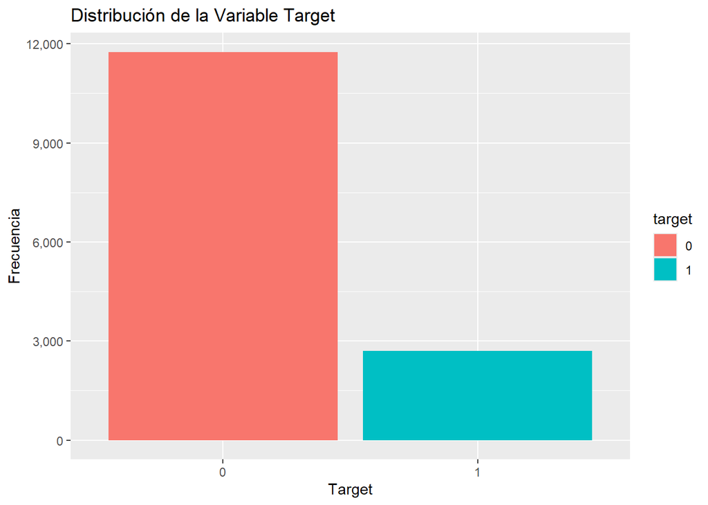

```r
# Distribución de la variable target
ggplot(df, aes(x = target, fill = target)) +
  geom_bar() +
  scale_y_continuous(labels = comma) +
  labs(title = "Distribución de la Variable Target", x = "Target", y = "Frecuencia")
```

La variable target es binaria. por lo tanto sus valores solo son 0 y 1, tenemos casi 4 veces mas personas clasificadas con 0 que con 1, esto puede hablarnos de un desbalanceo.

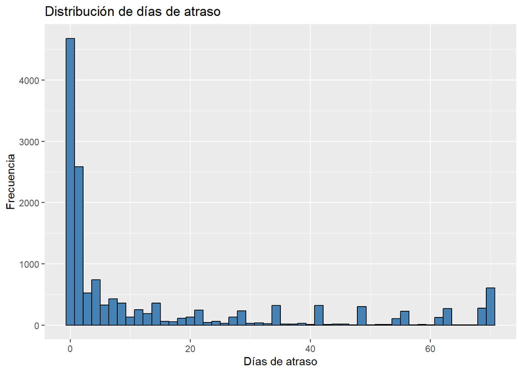

```r
# Distribución de días de atraso
ggplot(df, aes(x = max_days_late)) +
  geom_histogram(bins = 50, fill = "steelblue", color = "black") +
  labs(title = "Distribución de días de atraso", x = "Días de atraso", y = "Frecuencia")
```

Por lo general nuestros clientes no se atrasan, tenemos mas datos en primeros días de retraso que en los posteriores, aunque no sigue una distribución convencional y posiblemente existan valores considerados atípicos por la cantidad de días que tardaron, sin embargo es información relevante para nuestros modelos.

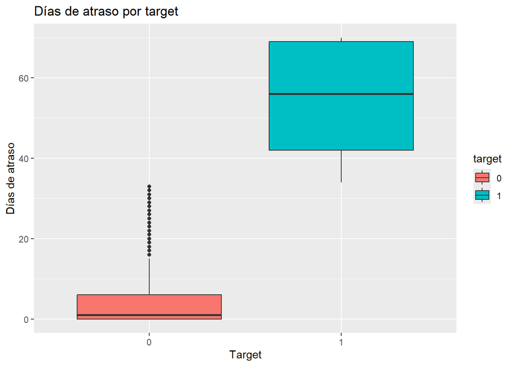

```r
# Boxplot de max_days_late por target
ggplot(df, aes(x = target, y = max_days_late, fill = target)) +
  geom_boxplot() +
  labs(title = "Días de atraso por target", x = "Target", y = "Días de atraso")
```

Para la clasificación de cero encontramos valores atípicos, estos se encuentran entre las dos categorías, fácilmente son los que podrían generar errores de clasificación a futuro, tambien vemos que la mediana es mucho mas pequeña que la media por lo que existe asimetría fuerte en la categoría 0 (muchos valores en primeros días), a diferencia de la categoría 1 que es casi simétrica.

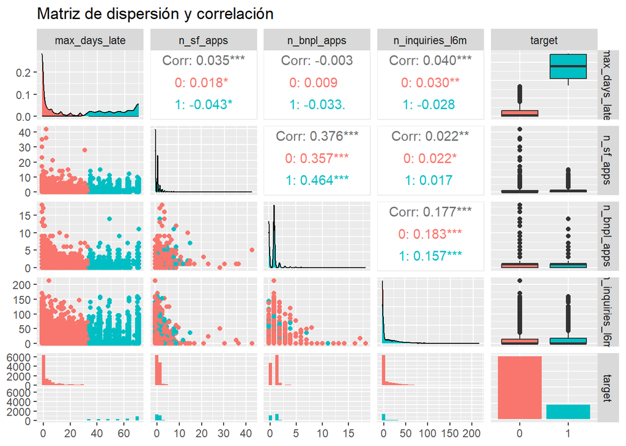

```r
# Matriz de dispersión y correlación
ggpairs(df %>% dplyr::select(max_days_late, n_sf_apps, n_bnpl_apps, n_inquiries_l6m, target),
              mapping = aes(color = target), title = "Matriz de dispersión y correlación")
```

En el pairplot observamos que la variable que mejor separa las categorías es la variable max_days_late, por lo que será la variable mas importante cuando creemos nuestros modelos

Dado que la variable mas importate es la mencionada anteriormente, utilizaremos dicha variable para clasificar a las personas como: - bajo riesgo: si han tenido un retraso máximo de 3 días - medio: si han retrasado entre 4 y 14 días - alto: si se han retrasado 15 días o mas

Creamos la categoría de riesgo sólo para análisis interpretativo

```r
# Creación de la categoría de riesgo
# Esta variable es útil para la parte de tasas fijas, pero no se usará directamente en el modelo predictivo.
df <- df %>%
  mutate(
    riesgo_cat = case_when( # Renombrado a riesgo_cat para evitar confusión con el score numérico
      between(max_days_late, 0, 3) ~ "bajo",
      between(max_days_late, 4, 14) ~ "medio",
      max_days_late >= 15 ~ "alto"
    ),
    riesgo_cat = factor(riesgo_cat, levels = c("bajo", "medio", "alto"))
  )
```

Visualización de categorías creadas

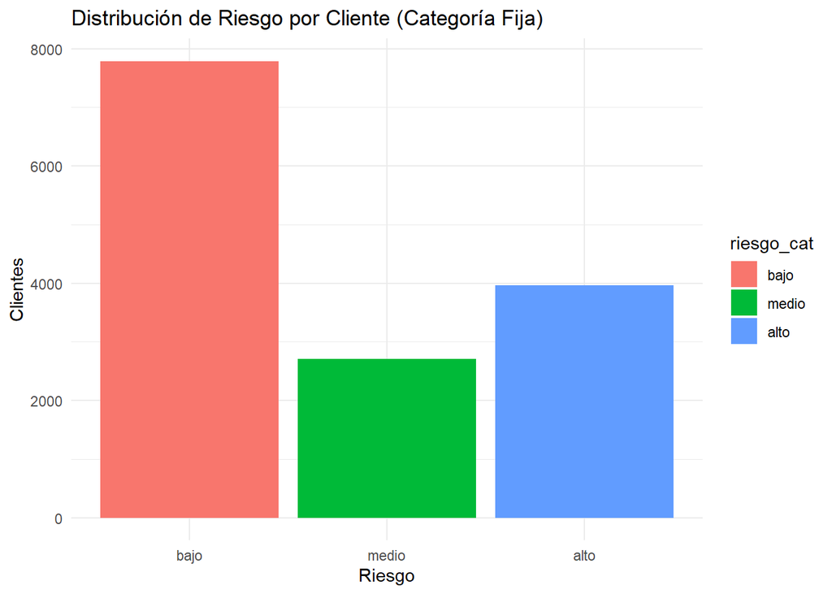

```r
df %>%
  count(riesgo_cat) %>%
  ggplot(aes(x = riesgo_cat, y = n, fill = riesgo_cat)) +
  geom_col() +
  labs(title = "Distribución de Riesgo por Cliente (Categoría Fija)", y = "Clientes", x = "Riesgo") +
  theme_minimal()
```

Según nuestras métricas asignadas arbitrariamente esta sería la distribución de las categorías de riesgo

## Parte dos

En esta sección importaremos los datos de crédito externos, los limpiaremos, codificaremos, crearemos nuevas variables útiles con base en esta base de datos y las agruparemos para agregarlas anuestro main_dataset posteriormente, teniendo en él toda la información por cliente

Importamos los datos de crédito

```r
df2 <- read_parquet("C:/Users/DELL/Downloads/credit_reports.parquet")
print(head(df2))
```

```
## # A tibble: 6 × 29
##   customer_id INQUIRY_TIME        CDC_INQUIRY_ID             INQUIRY_DATE
##         <int> <dttm>              <chr>                      <dttm>
## 1        4223 2022-04-01 00:32:36 710278-27993a6e-2885-48d4… 2022-03-31 18:00:00
## 2        4223 2022-04-01 00:32:36 710278-27993a6e-2885-48d4… 2022-03-31 18:00:00
## 3        4223 2022-04-01 00:32:36 710278-27993a6e-2885-48d4… 2022-03-31 18:00:00
## 4        3490 2022-02-15 02:30:22 622857-6b4e9d95-7491-40c3… 2022-02-14 18:00:00
## 5        6486 2022-06-25 01:57:14 875073-46a5f149-19db-4193… 2022-06-24 19:00:00
## 6        6486 2022-06-25 01:57:14 875073-46a5f149-19db-4193… 2022-06-24 19:00:00
## # ℹ 25 more variables: PREVENTION_KEY <chr>, CURRENCY <chr>, MAX_CREDIT <dbl>,
## #   CREDIT_LIMIT <dbl>, PAYMENT_AMOUNT <dbl>, UPDATE_DATE <dttm>,
## #   LOAN_OPENING_DATE <dttm>, LOAN_CLOSING_DATE <dttm>,
## #   WORST_DELAY_DATE <dttm>, REPORT_DATE <dttm>, LAST_PURCHASE_DATE <dttm>,
## #   LAST_PAYMENT_DATE <dttm>, PAYMENT_FREQUENCY <chr>, BUSINESS_TYPE <chr>,
## #   CREDIT_TYPE <chr>, ACCOUNT_TYPE <chr>, RESPONSABILITY_TYPE <chr>,
## #   TOTAL_PAYMENTS <dbl>, DELAYED_PAYMENTS <dbl>, CURRENT_PAYMENT <chr>, …
```

```r
print(summary(df2))
```

```
##   customer_id     INQUIRY_TIME                    CDC_INQUIRY_ID
##  Min.   :    1   Min.   :2021-04-29 22:50:03.74   Length:287356
##  1st Qu.: 2776   1st Qu.:2022-03-22 21:03:45.14   Class :character
##  Median : 6187   Median :2022-07-18 18:09:13.48   Mode  :character
##  Mean   : 6334   Mean   :2022-07-02 13:56:59.07
##  3rd Qu.: 9760   3rd Qu.:2022-10-27 00:27:07.93
##  Max.   :14416   Max.   :2023-05-17 15:20:36.89
##
##   INQUIRY_DATE                    PREVENTION_KEY       CURRENCY
##  Min.   :2021-04-28 19:00:00.00   Length:287356      Length:287356
##  1st Qu.:2022-03-21 18:00:00.00   Class :character   Class :character
##  Median :2022-07-17 19:00:00.00   Mode  :character   Mode  :character
##  Mean   :2022-07-01 19:44:25.38
##  3rd Qu.:2022-10-26 19:00:00.00
##  Max.   :2023-05-16 18:00:00.00
##  NA's   :89
##    MAX_CREDIT         CREDIT_LIMIT     PAYMENT_AMOUNT
##  Min.   :        0   Min.   :      0   Min.   :      0
##  1st Qu.:      548   1st Qu.:      0   1st Qu.:      0
##  Median :     2300   Median :    400   Median :      0
##  Mean   :    15280   Mean   :   5526   Mean   :   1671
##  3rd Qu.:     7483   3rd Qu.:   3000   3rd Qu.:    149
##  Max.   :404040416   Max.   :1900000   Max.   :1800000
##  NA's   :182         NA's   :8357      NA's   :89
##   UPDATE_DATE                  LOAN_OPENING_DATE
##  Min.   :2001-04-24 18:00:00   Min.   :1949-12-31 18:00:00.00
##  1st Qu.:2019-03-12 18:00:00   1st Qu.:2017-03-20 18:00:00.00
##  Median :2021-11-21 18:00:00   Median :2020-04-01 18:00:00.00
##  Mean   :2020-03-25 22:35:03   Mean   :2018-11-22 09:24:26.86
##  3rd Qu.:2022-06-14 19:00:00   3rd Qu.:2021-10-13 19:00:00.00
##  Max.   :2023-05-06 18:00:00   Max.   :2023-03-30 18:00:00.00
##  NA's   :89                    NA's   :89
##  LOAN_CLOSING_DATE                WORST_DELAY_DATE
##  Min.   :2000-08-27 19:00:00.00   Min.   :1998-10-09 19:00:00.00
##  1st Qu.:2017-01-29 18:00:00.00   1st Qu.:2018-04-29 19:00:00.00
##  Median :2020-01-26 18:00:00.00   Median :2021-05-30 19:00:00.00
##  Mean   :2018-10-24 16:45:09.91   Mean   :2019-08-10 21:14:42.97
##  3rd Qu.:2021-09-19 19:00:00.00   3rd Qu.:2022-04-19 19:00:00.00
##  Max.   :2023-03-30 18:00:00.00   Max.   :2023-04-11 18:00:00.00
##  NA's   :94747                    NA's   :202698
```

[output cut: 25 more lines]

```
##  Min.   : 0.000   Length:287356      Min.   : 0.000   Min.   :0
##  1st Qu.: 0.000   Class :character   1st Qu.: 0.000   1st Qu.:0
##  Median : 0.000   Mode  :character   Median : 0.000   Median :0
##  Mean   : 3.818                      Mean   : 4.279   Mean   :0
##  3rd Qu.: 1.000                      3rd Qu.: 2.000   3rd Qu.:0
##  Max.   :96.000                      Max.   :84.000   Max.   :0
##  NA's   :89                          NA's   :3210     NA's   :41941
##  CURRENT_BALANCE    BALANCE_DUE      BALANCE_DUE_WORST_DELAY
##  Min.   :      0   Min.   :      0   Min.   :      0
##  1st Qu.:      0   1st Qu.:      0   1st Qu.:      0
##  Median :      0   Median :      0   Median :      0
##  Mean   :   4578   Mean   :   2090   Mean   :   1672
##  3rd Qu.:    273   3rd Qu.:      0   3rd Qu.:    159
##  Max.   :3469743   Max.   :1800000   Max.   :1800000
##  NA's   :89        NA's   :89        NA's   :89
```

```r
print(colSums(is.na(df2)))
```

```
##             customer_id            INQUIRY_TIME          CDC_INQUIRY_ID
##                       0                       0                      89
##            INQUIRY_DATE          PREVENTION_KEY                CURRENCY
##                      89                      89                      89
##              MAX_CREDIT            CREDIT_LIMIT          PAYMENT_AMOUNT
##                     182                    8357                      89
##             UPDATE_DATE       LOAN_OPENING_DATE       LOAN_CLOSING_DATE
##                      89                      89                   94747
##        WORST_DELAY_DATE             REPORT_DATE      LAST_PURCHASE_DATE
##                  202698                      89                    4142
##       LAST_PAYMENT_DATE       PAYMENT_FREQUENCY           BUSINESS_TYPE
##                   31677                      89                      89
##             CREDIT_TYPE            ACCOUNT_TYPE     RESPONSABILITY_TYPE
##                      89                      89                      89
##          TOTAL_PAYMENTS        DELAYED_PAYMENTS         CURRENT_PAYMENT
##                   18645                      89                      89
##             WORST_DELAY TOTAL_REPORTED_PAYMENTS         CURRENT_BALANCE
##                    3210                   41941                      89
##             BALANCE_DUE BALANCE_DUE_WORST_DELAY
##                      89                      89
```

## Limpieza y Tratamiento de NA datos de crédito externos

Observamos que muchas variables tienen 89 valores faltantes, lo que nos dice que son personas sin crédito registrado, imputaremos los valores faltantes para las columnas numéricas con cero Nos aseguraremos que las columnas de fechas estén guardadas de esa manera

```r
# Eliminar observaciones sin crédito registrado (PAYMENT_FREQUENCY es un buen indicador de registro válido)
df2 <- df2 %>%
  filter(!is.na(PAYMENT_FREQUENCY))

# Imputar valores faltantes en columnas numéricas con 0
cols_to_impute_0_df2 <- c("MAX_CREDIT", "CREDIT_LIMIT", "PAYMENT_AMOUNT", "CURRENT_BALANCE",
                          "BALANCE_DUE", "BALANCE_DUE_WORST_DELAY", "DELAYED_PAYMENTS",
                          "WORST_DELAY", "TOTAL_PAYMENTS", "TOTAL_REPORTED_PAYMENTS")

df2 <- df2 %>%
  mutate(across(all_of(cols_to_impute_0_df2), ~replace_na(., 0)))

# Convertir columnas de fecha
date_cols_df2 <- c("LOAN_OPENING_DATE", "LOAN_CLOSING_DATE", "UPDATE_DATE",
                   "WORST_DELAY_DATE", "REPORT_DATE", "LAST_PURCHASE_DATE",
                   "LAST_PAYMENT_DATE")
df2 <- df2 %>%
  mutate(across(all_of(date_cols_df2), ~as_date(.)))

print(colSums(is.na(df2)))
```

```
##             customer_id            INQUIRY_TIME          CDC_INQUIRY_ID
##                       0                       0                       0
##            INQUIRY_DATE          PREVENTION_KEY                CURRENCY
##                       0                       0                       0
##              MAX_CREDIT            CREDIT_LIMIT          PAYMENT_AMOUNT
##                       0                       0                       0
##             UPDATE_DATE       LOAN_OPENING_DATE       LOAN_CLOSING_DATE
##                       0                       0                   94658
##        WORST_DELAY_DATE             REPORT_DATE      LAST_PURCHASE_DATE
##                  202609                       0                    4053
##       LAST_PAYMENT_DATE       PAYMENT_FREQUENCY           BUSINESS_TYPE
##                   31588                       0                       0
##             CREDIT_TYPE            ACCOUNT_TYPE     RESPONSABILITY_TYPE
##                       0                       0                       0
##          TOTAL_PAYMENTS        DELAYED_PAYMENTS         CURRENT_PAYMENT
##                       0                       0                       0
##             WORST_DELAY TOTAL_REPORTED_PAYMENTS         CURRENT_BALANCE
##                       0                       0                       0
##             BALANCE_DUE BALANCE_DUE_WORST_DELAY
##                       0                       0
```

Únicamente nos quedan valores faltantes en las columnas de fecha, cada una con diferente cantidad de valores pero no podemos borrar las filas con esas ausencias, ya que perderíamos mucha información relevante

## Ingeniería de datos

En esta sección crearemos nuevas variables útiles para las características de riesgo externo, en caso de crear algún NA reemplazará por cero

```r
# Ingeniería de Variables en df2
df2 <- df2 %>%
  mutate(
    # Tiempo de vida del crédito en meses
    tiempo_credito_meses = as.numeric(interval(LOAN_OPENING_DATE, UPDATE_DATE), "months"),
    # Uso de crédito: Saldo actual / Límite de crédito. Manejar división por cero.
    uso_credito_pct = if_else(CREDIT_LIMIT > 0, CURRENT_BALANCE / CREDIT_LIMIT, 0),
    # Porcentaje de pagos atrasados: Pagos atrasados / Total de pagos.
    pagos_tarde_pct = if_else(TOTAL_PAYMENTS > 0, DELAYED_PAYMENTS / TOTAL_PAYMENTS, 0)
  ) %>%
  # Limitar uso_credito_pct a 1 (no puede ser más del 100%)
  mutate(uso_credito_pct = pmin(uso_credito_pct, 1))

# Reemplazamos posibles NAs
df2 <- df2 %>%
  mutate(across(c(tiempo_credito_meses, uso_credito_pct, pagos_tarde_pct), ~replace_na(., 0)))
```

NOTA CLAVE DEL PROBLEMA: La relación es de uno a muchos (un customer_id en main_dataset puede tener múltiples registros en credit_reports). Para usar esta información en el modelo del main_dataset (que es por loan_id, y cada loan_id tiene un customer_id), necesitamos resumir el historial de credit_reports por customer_id.

## Agregación de credit_reports a nivel customer_id

```r
df2_aggregated <- df2 %>%
  group_by(customer_id) %>%
  summarise(
    # Métricas de uso de crédito
    mean_uso_credito_ext = mean(uso_credito_pct, na.rm = TRUE),
    max_uso_credito_ext = max(uso_credito_pct, na.rm = TRUE),

    # Métricas de atraso
    max_worst_delay_ext = max(WORST_DELAY, na.rm = TRUE), # Peor atraso en cualquier crédito externo
    mean_delayed_payments_pct_ext = mean(pagos_tarde_pct, na.rm = TRUE),

    # Cantidad y tipo de créditos
    n_external_credits = n(), # Número total de créditos externos reportados
    n_distinct_credit_types = n_distinct(CREDIT_TYPE),

    # Historial de crédito
    mean_tiempo_credito_meses_ext = mean(tiempo_credito_meses, na.rm = TRUE),
    max_total_payments_ext = max(TOTAL_PAYMENTS, na.rm = TRUE),

  ) %>%
  ungroup()

# Verificamos que no haya ningún NA en la agrupación que creamos
colSums(is.na(df2_aggregated))
```

```
##                   customer_id          mean_uso_credito_ext
##                             0                             0
##           max_uso_credito_ext           max_worst_delay_ext
##                             0                             0
## mean_delayed_payments_pct_ext            n_external_credits
##                             0                             0
##       n_distinct_credit_types mean_tiempo_credito_meses_ext
##                             0                             0
##        max_total_payments_ext
##                             0
```

```r
# Resumen
summary(df2_aggregated)
```

```
##   customer_id    mean_uso_credito_ext max_uso_credito_ext max_worst_delay_ext
##  Min.   :    1   Min.   :0.00000      Min.   :0.0000      Min.   : 0.00
##  1st Qu.: 2698   1st Qu.:0.09056      1st Qu.:1.0000      1st Qu.:13.00
##  Median : 5694   Median :0.17677      Median :1.0000      Median :34.00
##  Mean   : 6114   Mean   :0.21368      Mean   :0.8974      Mean   :42.02
##  3rd Qu.: 9429   3rd Qu.:0.29917      3rd Qu.:1.0000      3rd Qu.:84.00
##  Max.   :14416   Max.   :1.00000      Max.   :1.0000      Max.   :84.00
##  mean_delayed_payments_pct_ext n_external_credits n_distinct_credit_types
##  Min.   : 0.00000              Min.   :  1.00     Min.   : 1.000
##  1st Qu.: 0.09635              1st Qu.: 11.00     1st Qu.: 4.000
##  Median : 0.43310              Median : 22.00     Median : 5.000
##  Mean   : 0.89468              Mean   : 31.32     Mean   : 5.184
##  3rd Qu.: 1.18198              3rd Qu.: 41.00     3rd Qu.: 7.000
##  Max.   :25.00000              Max.   :269.00     Max.   :14.000
##  mean_tiempo_credito_meses_ext max_total_payments_ext
##  Min.   :  0.4415              Min.   :   0.0
##  1st Qu.: 10.8016              1st Qu.:  33.0
##  Median : 16.8158              Median :  96.0
##  Mean   : 20.5255              Mean   : 234.1
##  3rd Qu.: 25.6553              3rd Qu.: 360.0
##  Max.   :183.0418              Max.   :1800.0
```

# PARTE 3: Integración de Datos y Modelado Final

En esta sección se unirá la información de las bases de datos y las variables creadas por cliente según su id, crearemos unos modelos de aprendizaje automático, finalmente compararemos las métricas por modelo.

```r
# Unir por costumer_id
df_final_model <- left_join(df, df2_aggregated, by = "customer_id")
colSums(is.na(df_final_model))
```

```
##                   customer_id                       loan_id
##                             0                             0
##         ACC_CREATION_DATETIME          APPLICATION_DATETIME
##                             0                             0
##     LOAN_ORIGINATION_DATETIME                 max_days_late
##                             0                             0
##                        target   account_to_application_days
##                             0                             0
##                     n_sf_apps                first_app_date
##                             0                          7648
##                 last_app_date                   n_bnpl_apps
##                          7648                             0
##          n_bnpl_approved_apps           first_bnpl_app_date
##                             0                          5715
##            last_bnpl_app_date               n_inquiries_l3m
##                          5715                             0
##               n_inquiries_l6m                    riesgo_cat
##                             0                             0
##          mean_uso_credito_ext           max_uso_credito_ext
##                          5282                          5282
##           max_worst_delay_ext mean_delayed_payments_pct_ext
##                          5282                          5282
##            n_external_credits       n_distinct_credit_types
##                          5282                          5282
## mean_tiempo_credito_meses_ext        max_total_payments_ext
##                          5282                          5282
```

Los NA significa que el cliente con ese ID no tiene datos externos, posibliemente no ha solicitado ningún crédito fuera de este negocio. Los NA serán reemplazados por cero en las variables que provienen de la base de datos de crédito

```r
# Reemplazamos NAs
df_final_model <- df_final_model %>%
  mutate(across(c(mean_uso_credito_ext, max_uso_credito_ext,
                  max_worst_delay_ext, mean_delayed_payments_pct_ext,
                  n_external_credits, n_distinct_credit_types,
                  mean_tiempo_credito_meses_ext, max_total_payments_ext),
                ~replace_na(., 0)))
```

Selección de variables para nuestro modelo de aprendizaje automático, omitiremos las variables de fecha de nuestro main_dataset

```r
# Incluimos las variables numéricas y la variable objetivo de nuetro nuevo dataset

vars_usar_final <- c("target", "max_days_late", "n_sf_apps", "n_bnpl_apps",
                     "n_bnpl_approved_apps", "n_inquiries_l3m", "n_inquiries_l6m",
                     "account_to_application_days",
                     # Nuevas variables de credit_reports agregadas
                     "mean_uso_credito_ext", "max_uso_credito_ext",
                     "max_worst_delay_ext", "mean_delayed_payments_pct_ext",
                     "n_external_credits", "n_distinct_credit_types",
                     "mean_tiempo_credito_meses_ext", "max_total_payments_ext"
)


df_model_final <- df_final_model %>% dplyr::select(all_of(vars_usar_final))
df_model_final <- df_model_final %>%
  mutate(across(where(is.integer), as.numeric))

summary(df_model_final)
```

```
##  target    max_days_late     n_sf_apps        n_bnpl_apps
##  0:11754   Min.   : 0.00   Min.   : 0.0000   Min.   : 0.0000
##  1: 2700   1st Qu.: 0.00   1st Qu.: 0.0000   1st Qu.: 0.0000
##            Median : 2.00   Median : 0.0000   Median : 1.0000
##            Mean   :14.28   Mean   : 0.7788   Mean   : 0.7387
##            3rd Qu.:20.00   3rd Qu.: 1.0000   3rd Qu.: 1.0000
##            Max.   :70.00   Max.   :42.0000   Max.   :18.0000
##  n_bnpl_approved_apps n_inquiries_l3m   n_inquiries_l6m
##  Min.   : 0.0000      Min.   :  0.000   Min.   :  0.00
##  1st Qu.: 0.0000      1st Qu.:  0.000   1st Qu.:  0.00
##  Median : 0.0000      Median :  0.000   Median :  0.00
##  Mean   : 0.1602      Mean   :  6.504   Mean   : 10.76
##  3rd Qu.: 0.0000      3rd Qu.:  0.000   3rd Qu.: 15.00
##  Max.   :15.0000      Max.   :170.000   Max.   :213.00
##  account_to_application_days mean_uso_credito_ext max_uso_credito_ext
##  Min.   :  0.0               Min.   :0.0000       Min.   :0.0000
##  1st Qu.:  0.0               1st Qu.:0.0000       1st Qu.:0.0000
##  Median :103.0               Median :0.0771       Median :1.0000
##  Mean   :163.5               Mean   :0.1356       Mean   :0.5694
##  3rd Qu.:271.8               3rd Qu.:0.2207       3rd Qu.:1.0000
##  Max.   :901.0               Max.   :1.0000       Max.   :1.0000
##  max_worst_delay_ext mean_delayed_payments_pct_ext n_external_credits
##  Min.   : 0.00       Min.   : 0.00000              Min.   :  0.00
##  1st Qu.: 0.00       1st Qu.: 0.00000              1st Qu.:  0.00
##  Median :13.00       Median : 0.06919              Median :  9.00
##  Mean   :26.66       Mean   : 0.56773              Mean   : 19.87
##  3rd Qu.:53.00       3rd Qu.: 0.68072              3rd Qu.: 28.00
##  Max.   :84.00       Max.   :25.00000              Max.   :269.00
##  n_distinct_credit_types mean_tiempo_credito_meses_ext max_total_payments_ext
##  Min.   : 0.00           Min.   :  0.000               Min.   :   0.0
##  1st Qu.: 0.00           1st Qu.:  0.000               1st Qu.:   0.0
##  Median : 4.00           Median :  9.963               Median :  26.0
##  Mean   : 3.29           Mean   : 13.025               Mean   : 148.5
##  3rd Qu.: 6.00           3rd Qu.: 20.011               3rd Qu.: 102.0
##  Max.   :14.00           Max.   :183.042               Max.   :1800.0
```

Del summary anterior llama la atención la proporción de datos en target, cero tiene una proporción mucho mayor, de nuevo hablamos de un desbalance para la costrucción del modelo de aprendizaje automático

Realizamos un diagrama de correlación para evitar tener multicolinealidad perfecta, que las variables aporten lo mismo y/o afecten a nuestro modelo

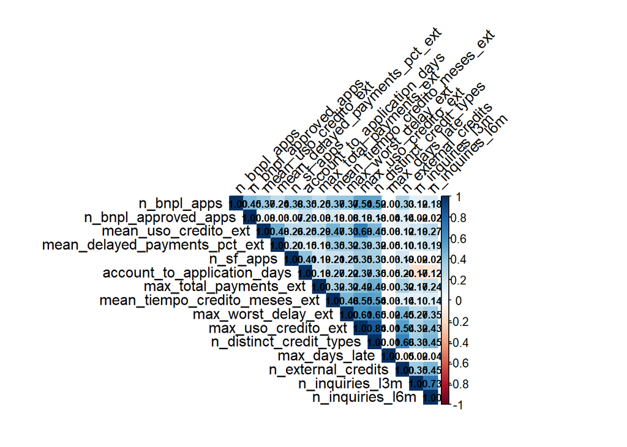

```r
# Correlación de las variables del modelo final
cor_matrix_final <- cor(dplyr::select(df_model_final, where(is.numeric)), use = "pairwise.complete.obs")
corrplot(cor_matrix_final, method = "color", type = "upper", order = "hclust",
         addCoef.col = "black", tl.col = "black", tl.srt = 45, number.cex = 0.7)
```

Realizamos la partición en datos de entrenamiento y prueba, utilizando el 80% de los datos para entrenar el modelo

```r
# Partición en datos de entrenamiento y prueba
set.seed(42)
part <- createDataPartition(df_model_final$target, p = 0.8, list = FALSE)
train <- df_model_final[part, ]
test <- df_model_final[-part, ]
table(train$target)
```

```
##
##    0    1
## 9404 2160
```

Como tenemos muchos mas datos en la clase 0 realizaremos un balanceo en nuestros datos de entrenamiento

```r
# Balanceo con ROSE
train_bal <- ROSE(target ~ ., data = train, seed = 42)$data
# Verificamos el balanceo
table(train_bal$target)
```

```
##
##    0    1
## 5761 5803
```

Creamos una función para los resultados de las métricas de nuestros modelos y poderlos comparar posteriormente con una tabla

```r
# Función para las métricas
eval_metrics <- function(pred, obs, modelo) {
  pred <- factor(pred, levels = c("0", "1"))
  obs <- factor(obs, levels = c("0", "1"))
  cm <- confusionMatrix(pred, obs, positive = "1")
  f1 <- F1_Score(pred, obs, positive = "1")
  prec <- cm$byClass["Precision"]
  rec <- cm$byClass["Sensitivity"]
  acc <- cm$overall["Accuracy"]
  kappa <- cm$overall["Kappa"]
  data.frame(Modelo = modelo, Accuracy = acc, Kappa = kappa,
             F1 = f1, Precision = prec, Recall = rec)
}
resultados <- list()
```

## Regresión logística

```r
modelo_glm <- glm(target ~ ., data = train_bal, family = "binomial")
pred_prob_glm <- predict(modelo_glm, newdata = test, type = "response")
pred_glm_class <- as.factor(ifelse(pred_prob_glm > 0.7, 1, 0)) # Clasificación binaria con umbral 0.7
res_glm <- eval_metrics(pred_glm_class, test$target, "Regresión Logística")
print(confusionMatrix(pred_glm_class, test$target, positive = "1"))
```

```
## Confusion Matrix and Statistics
##
##           Reference
## Prediction    0    1
##          0 2329    0
##          1   21  540
##
##                Accuracy : 0.9927
##                  95% CI : (0.9889, 0.9955)
##     No Information Rate : 0.8131
##     P-Value [Acc > NIR] : < 2.2e-16
##
##                   Kappa : 0.9764
##
##  Mcnemar's Test P-Value : 1.275e-05
##
##             Sensitivity : 1.0000
##             Specificity : 0.9911
##          Pos Pred Value : 0.9626
##          Neg Pred Value : 1.0000
##              Prevalence : 0.1869
##          Detection Rate : 0.1869
##    Detection Prevalence : 0.1941
##       Balanced Accuracy : 0.9955
##
##        'Positive' Class : 1
##
```

```r
resultados[["Regresión Logística"]] <- res_glm
```

## Árbol de decisión

```r
# Usamos rpart para árboles de clasificación
modelo_dt <- rpart(target ~ ., data = train_bal, method = "class",
                   control = rpart.control(minsplit = 20, cp = 0.01)) # minsplit y cp para controlar complejidad
pred_dt <- predict(modelo_dt, newdata = test, type = "class")
res_dt <- eval_metrics(pred_dt, test$target, "Árbol de Decisión")
print(confusionMatrix(pred_dt, test$target, positive = "1"))
```

```
## Confusion Matrix and Statistics
##
##           Reference
## Prediction    0    1
##          0 2325    0
##          1   25  540
##
##                Accuracy : 0.9913
##                  95% CI : (0.9873, 0.9944)
##     No Information Rate : 0.8131
##     P-Value [Acc > NIR] : < 2.2e-16
##
##                   Kappa : 0.972
##
##  Mcnemar's Test P-Value : 1.587e-06
##
##             Sensitivity : 1.0000
##             Specificity : 0.9894
##          Pos Pred Value : 0.9558
##          Neg Pred Value : 1.0000
##              Prevalence : 0.1869
##          Detection Rate : 0.1869
##    Detection Prevalence : 0.1955
##       Balanced Accuracy : 0.9947
##
##        'Positive' Class : 1
##
```

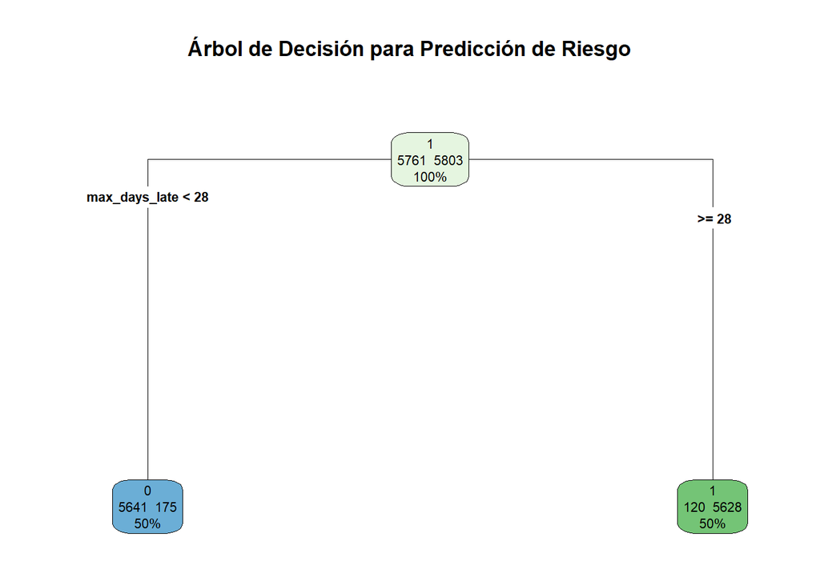

```r
resultados[["Árbol de Decisión"]] <- res_dt

# Visualización del Árbol de Decisión (opcional, puede ser grande)
 rpart.plot(modelo_dt, type = 4, extra = 101, fallen.leaves = TRUE, cex = 0.7,
            main = "Árbol de Decisión para Predicción de Riesgo")
```

Con el árbol de decisión verificamos que la variable más importante es mas_day_late

## XGBoost

```r
train_x <- as.matrix(dplyr::select(train_bal, -target))
train_y <- as.numeric(train_bal$target) - 1 # 0 y 1 para XGBoost
dtrain <- xgb.DMatrix(data = train_x, label = train_y)

# Parámetros optimizados para XGBoost (puedes ajustar más si es necesario)
params <- list(objective = "binary:logistic",
               eval_metric = "auc",
               eta = 0.1,      # Tasa de aprendizaje
               max_depth = 4,  # Profundidad máxima del árbol
               subsample = 0.8, # Submuestreo de filas
               colsample_bytree = 0.8 # Submuestreo de columnas
               )

xgb_model <- xgb.train(params = params, dtrain, nrounds = 150, verbose = 0) # Aumentar nrounds para mejor rendimiento

# Predicciones de probabilidad en el conjunto de prueba
test_x <- as.matrix(dplyr::select(test, -target))
pred_prob_xgb <- predict(xgb_model, test_x)
pred_xgb_class <- as.factor(ifelse(pred_prob_xgb > 0.5, 1, 0)) # Clasificación binaria con umbral 0.5

res_xgb <- eval_metrics(pred_xgb_class, test$target, "XGBoost")
print(confusionMatrix(pred_xgb_class, test$target, positive = "1"))
```

```
## Confusion Matrix and Statistics
##
##           Reference
## Prediction    0    1
##          0 2318    0
##          1   32  540
##
##                Accuracy : 0.9889
##                  95% CI : (0.9844, 0.9924)
##     No Information Rate : 0.8131
##     P-Value [Acc > NIR] : < 2.2e-16
##
##                   Kappa : 0.9644
##
##  Mcnemar's Test P-Value : 4.251e-08
##
##             Sensitivity : 1.0000
##             Specificity : 0.9864
##          Pos Pred Value : 0.9441
##          Neg Pred Value : 1.0000
##              Prevalence : 0.1869
##          Detection Rate : 0.1869
##    Detection Prevalence : 0.1979
##       Balanced Accuracy : 0.9932
##
##        'Positive' Class : 1
##
```

```r
resultados[["XGBoost"]] <- res_xgb
```

## Bosque aleatorio

```r
set.seed(42)
modelo_rf <- randomForest(target ~ ., data = train_bal, ntree = 100, maxnodes = 80)
pred_rf <- predict(modelo_rf, newdata = test)
res_rf <- eval_metrics(pred_rf, test$target, "Random Forest")
print(confusionMatrix(pred_rf, test$target, positive = "1"))
```

```
## Confusion Matrix and Statistics
##
##           Reference
## Prediction    0    1
##          0 2310    0
##          1   40  540
##
##                Accuracy : 0.9862
##                  95% CI : (0.9812, 0.9901)
##     No Information Rate : 0.8131
##     P-Value [Acc > NIR] : < 2.2e-16
##
##                   Kappa : 0.9557
##
##  Mcnemar's Test P-Value : 6.984e-10
##
##             Sensitivity : 1.0000
##             Specificity : 0.9830
##          Pos Pred Value : 0.9310
##          Neg Pred Value : 1.0000
##              Prevalence : 0.1869
##          Detection Rate : 0.1869
##    Detection Prevalence : 0.2007
##       Balanced Accuracy : 0.9915
##
##        'Positive' Class : 1
##
```

```r
resultados[["Random Forest"]] <- res_rf
```

Error OOB para bosque aleatorio

```r
# Tabla error OOB
oob_error <- modelo_rf$err.rate[modelo_rf$ntree, "OOB"]
cat("Error OOB final:", round(oob_error * 100, 2), "%\n")
```

```
## Error OOB final: 2.53 %
```

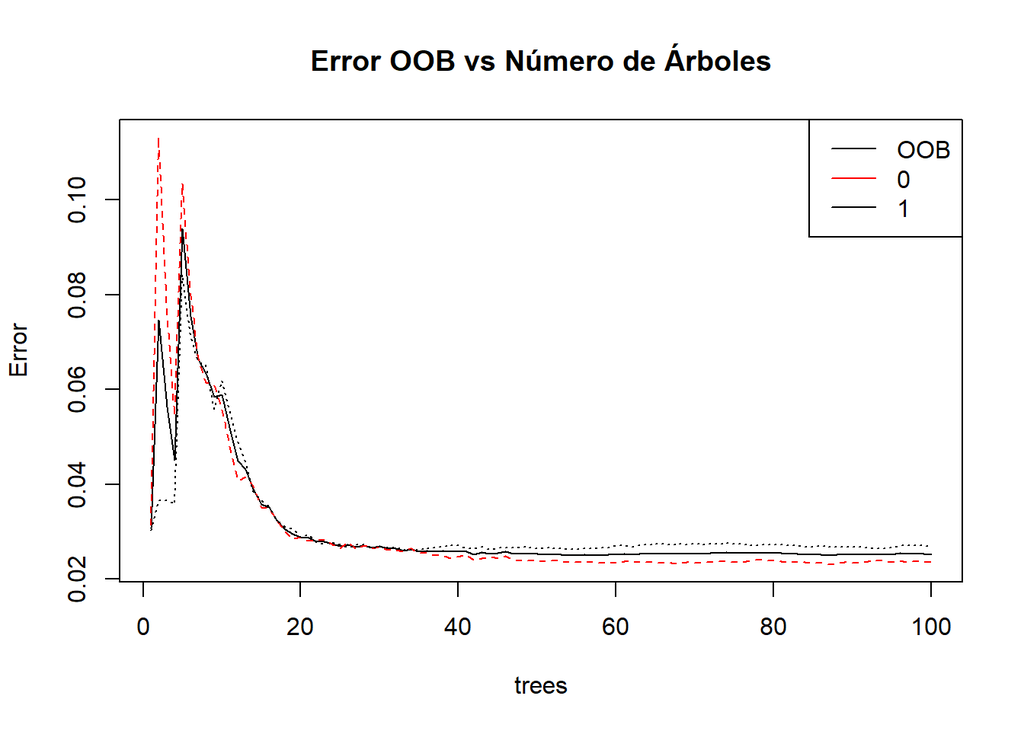

```r
plot(modelo_rf,
     main = "Error OOB vs Número de Árboles",
     col = c("black", "red"))
legend("topright",
       legend = colnames(modelo_rf$err.rate),
       col = c("black", "red"),
       lty = 1)
```

```r
oob_error <- modelo_rf$err.rate[modelo_rf$ntree, "OOB"]
cat("Error OOB final:", round(oob_error * 100, 2), "%\n")
```

```
## Error OOB final: 2.53 %
```

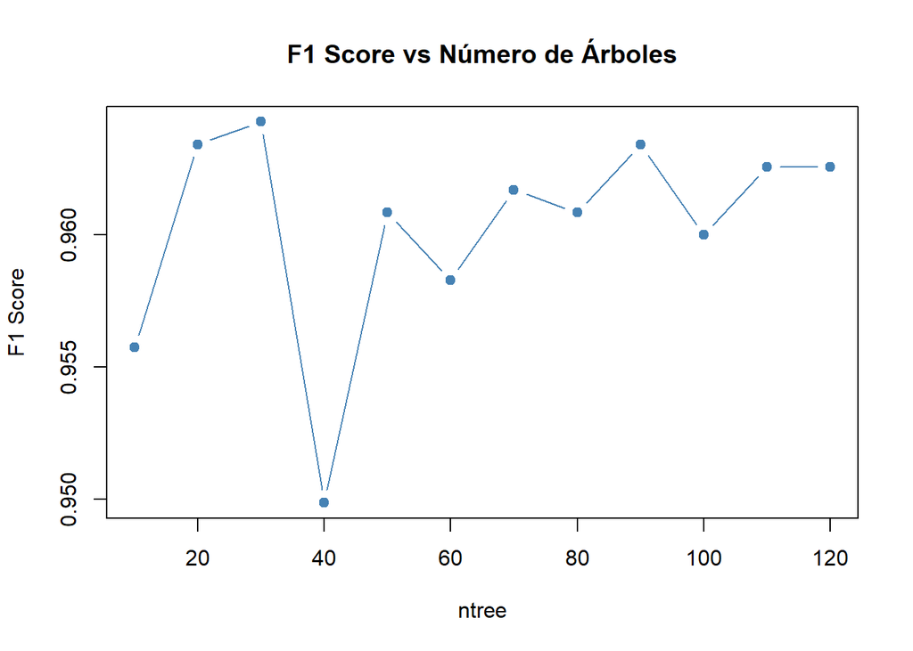

```r
# F1 vs Número de árboles
n_arboles <- seq(10, 120, by = 10)
f1_scores <- sapply(n_arboles, function(n) {
  m <- randomForest(target ~ ., data = train_bal, ntree = n)
  pred <- predict(m, newdata = test)
  F1_Score(pred, test$target, positive = "1")
})
plot(n_arboles, f1_scores, type = "b", pch = 19, col = "steelblue",
     main = "F1 Score vs Número de Árboles", xlab = "ntree", ylab = "F1 Score")
```

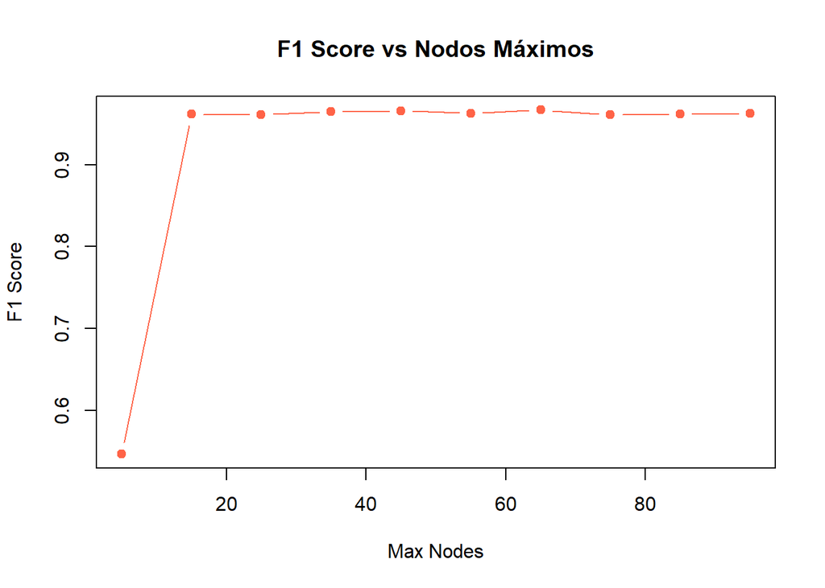

```r
# F1 vs Número de nodos
max_nodes <- seq(5, 100, by = 10)
f1_nodes <- sapply(max_nodes, function(depth) {
  m <- randomForest(target ~ ., data = train_bal, ntree = 90, maxnodes = depth)
  pred <- predict(m, newdata = test)
  F1_Score(pred, test$target, positive = "1")
})
plot(max_nodes, f1_nodes, type = "b", pch = 19, col = "tomato",
     main = "F1 Score vs Nodos Máximos", xlab = "Max Nodes", ylab = "F1 Score")
```

## Red Neuronal

```r
set.seed(42)
nn_model <- nnet(target ~ ., data = train_bal, size = 5, decay = 0.01, maxit = 100, trace = FALSE)
pred_nn <- predict(nn_model, test, type = "class")
pred_nn <- factor(pred_nn, levels = c("0", "1"))
res_nn <- eval_metrics(pred_nn, test$target, "Neural Net")
print(confusionMatrix(pred_nn, test$target, positive = "1"))
```

```
## Confusion Matrix and Statistics
##
##           Reference
## Prediction    0    1
##          0 2300    0
##          1   50  540
##
##                Accuracy : 0.9827
##                  95% CI : (0.9773, 0.9871)
##     No Information Rate : 0.8131
##     P-Value [Acc > NIR] : < 2.2e-16
##
##                   Kappa : 0.945
##
##  Mcnemar's Test P-Value : 4.219e-12
##
##             Sensitivity : 1.0000
##             Specificity : 0.9787
##          Pos Pred Value : 0.9153
##          Neg Pred Value : 1.0000
##              Prevalence : 0.1869
##          Detection Rate : 0.1869
##    Detection Prevalence : 0.2042
##       Balanced Accuracy : 0.9894
##
##        'Positive' Class : 1
##
```

```r
resultados[["NeuralNet"]] <- res_nn
```